# Project_Stat

Import the necessary libraries

```python
import numpy as np
import pandas as pd
import seaborn as sns
import matplotlib.pyplot as plt
%matplotlib inline
```

Read the data as a data frame

```python
insur = pd.read_csv('D:/Python_Files_Data/insurance.csv')
```

```python
insur.head()
```

|  | age | sex | bmi | children | smoker | region | charges |
| --- | --- | --- | --- | --- | --- | --- | --- |
| 0 | 19 | female | 27.900 | 0 | yes | southwest | 16884.92400 |
| 1 | 18 | male | 33.770 | 1 | no | southeast | 1725.55230 |
| 2 | 28 | male | 33.000 | 3 | no | southeast | 4449.46200 |
| 3 | 33 | male | 22.705 | 0 | no | northwest | 21984.47061 |
| 4 | 32 | male | 28.880 | 0 | no | northwest | 3866.85520 |

EDA - shape & type of Data

```python
insur.shape
```

```
(1338, 7)
```

```python
insur.info()
```

```
<class 'pandas.core.frame.DataFrame'>
RangeIndex: 1338 entries, 0 to 1337
Data columns (total 7 columns):
 #   Column    Non-Null Count  Dtype
---  ------    --------------  -----
 0   age       1338 non-null   int64
 1   sex       1338 non-null   object
 2   bmi       1338 non-null   float64
 3   children  1338 non-null   int64
 4   smoker    1338 non-null   object
 5   region    1338 non-null   object
 6   charges   1338 non-null   float64
dtypes: float64(2), int64(2), object(3)
memory usage: 73.3+ KB
```

EDA - Checking the presence of missing values

```python
insur.isnull().sum()
```

```
age         0
sex         0
bmi         0
children    0
smoker      0
region      0
charges     0
dtype: int64
```

EDA - 5 point summary of numerical attributes

```python
insur.describe()
```

|  | age | bmi | children | charges |
| --- | --- | --- | --- | --- |
| count | 1338.000000 | 1338.000000 | 1338.000000 | 1338.000000 |
| mean | 39.207025 | 30.663397 | 1.094918 | 13270.422265 |
| std | 14.049960 | 6.098187 | 1.205493 | 12110.011237 |
| min | 18.000000 | 15.960000 | 0.000000 | 1121.873900 |
| 25% | 27.000000 | 26.296250 | 0.000000 | 4740.287150 |
| 50% | 39.000000 | 30.400000 | 1.000000 | 9382.033000 |
| 75% | 51.000000 | 34.693750 | 2.000000 | 16639.912515 |
| max | 64.000000 | 53.130000 | 5.000000 | 63770.428010 |

EDA - Distribution of ‘bmi’, ‘age’ and ‘charges’ columns

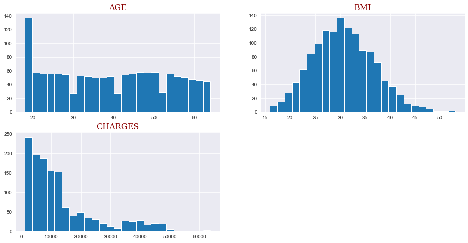

```python
font = {'family': 'serif',
        'color':  'darkred',
        'weight': 'normal',
        'size': 16,
        }

fig = plt.figure(figsize=(16,8))

ax = fig.add_subplot(2, 2, 1)
plt.hist(insur['age'],bins=25)
ax.set_title('AGE', fontdict=font)

ax = fig.add_subplot(2, 2, 2)
plt.hist(insur['bmi'],bins=25)
ax.set_title('BMI', fontdict=font)


ax = fig.add_subplot(2, 2, 3)
plt.hist(insur['charges'],bins=25)
ax.set_title('CHARGES', fontdict=font)
```

## Note:-

- Here we can see that only "BMI" data has normal distribution.
- "CHARGES" columns seems to be positivey skewed.
- "AGE" column seems to be flat.

EDA - Measure of skewness of ‘bmi’, ‘age’ and ‘charges’ columns

```python
m=[]             #List of Means
mo_de=[]         #List of Modes
med_ian=[]       #List of Medians
IQR=[]           #List of IQR Values
NumData=['age','bmi','charges']  #Creating a List of Numerical Data
```

```python
for x in range(len(NumData)):
      a = insur[NumData[x]].mean()
      m.append(a)

m
```

```
[39.20702541106129, 30.663396860986538, 13270.422265141257]
```

```python
for x in range(len(NumData)):
       b = insur[NumData[x]].mode()
       mo_de.append(b)

mo_de
```

```
[0    18
 dtype: int64,
 0    32.3
 dtype: float64,
 0    1639.5631
 dtype: float64]
```

```python
for x in range(len(NumData)):
       c = insur[NumData[x]].median()
       med_ian.append(c)

med_ian
```

```
[39.0, 30.4, 9382.033]
```

```python
for x in range(len(NumData)):
      p =(insur[NumData[x]].quantile(0.75))-(insur[NumData[x]].quantile(0.25))
      IQR.append(p)

IQR
```

```
[24.0, 8.3975, 11899.625365]
```

```python
attribute_list=[m,med_ian,IQR]          #Forming a list of list for converting to DataFrame
df = pd.DataFrame(attribute_list)       #converting a list of list into DataFrame
dispersion = df.transpose()             #converting a dataframe into its transpose as the desired result demands
dispersion.columns=['Mean','Median','IQR'] # Naming the columns
dispersion['NumAttributes']=NumData        #adding one more column to to DataFrame to set new index
dispersion.set_index('NumAttributes',inplace=True) #setting the recently added column as new index
dispersion
```

| NumAttributes | Mean | Median | IQR |
| --- | --- | --- | --- |
| age | 39.207025 | 39.000 | 24.000000 |
| bmi | 30.663397 | 30.400 | 8.397500 |
| charges | 13270.422265 | 9382.033 | 11899.625365 |

```python
skew_ness=[]
NumData=['age','bmi','charges']  #List of Numerical Data
for x in range(len(NumData)):
       c = insur[NumData[x]].skew()
       skew_ness.append(c)

skew_ness
```

```
[0.05567251565299186, 0.2840471105987448, 1.5158796580240388]
```

```python
dispersion['Skewness']=skew_ness
dispersion
```

| NumAttributes | Mean | Median | IQR | Skewness |
| --- | --- | --- | --- | --- |
| age | 39.207025 | 39.000 | 24.000000 | 0.055673 |
| bmi | 30.663397 | 30.400 | 8.397500 | 0.284047 |
| charges | 13270.422265 | 9382.033 | 11899.625365 | 1.515880 |

EDA - Checking the presence of outliers in ‘bmi’, ‘age’ and ‘charges columns

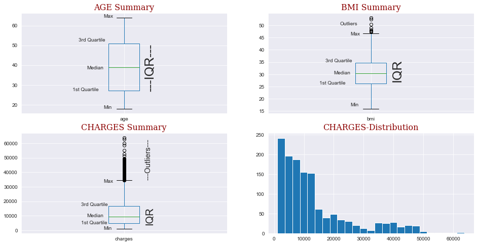

```python
font = {'family': 'serif',
        'color':  'darkred',
        'weight': 'normal',
        'size': 16,
        }

fig = plt.figure(figsize=(16,8))

ax = fig.add_subplot(2, 2, 1)
insur.boxplot(column='age')
ax.set_title('AGE Summary', fontdict=font)

plt.text(x=0.90, y=64.00, s="Max")
plt.text(x=0.78, y=52.00, s="3rd Quartile")
plt.text(x=0.82, y=38.00, s="Median")
plt.text(x=0.75, y=27.00, s="1st Quartile")
plt.text(x=0.9, y=18.00, s="Min")
plt.text(x=1.1, y=28, s="---IQR---", rotation=90, size=25)


ax = fig.add_subplot(2, 2, 2)
insur.boxplot(column='bmi')
ax.set_title('BMI Summary', fontdict=font)

plt.text(x=0.90, y=46.00, s="Max")
plt.text(x=0.78, y=35.00, s="3rd Quartile")
plt.text(x=0.82, y=30.00, s="Median")
plt.text(x=0.75, y=26.00, s="1st Quartile")
plt.text(x=0.9, y=17.00, s="Min")
plt.text(x=0.85, y=50.00, s="Outliers")
plt.text(x=1.1, y=28, s="IQR", rotation=90, size=25)


ax = fig.add_subplot(2, 2, 3)
insur.boxplot(column='charges')
ax.set_title('CHARGES Summary', fontdict=font)

plt.text(x=0.90, y=33000.00, s="Max")
plt.text(x=0.79, y=17000.00, s="3rd Quartile")
plt.text(x=0.82, y=9000.00, s="Median")
plt.text(x=0.79, y=4500.00, s="1st Quartile")
plt.text(x=0.9, y=500.00, s="Min")
plt.text(x=1.1, y=5000, s="IQR", rotation=90, size=20)
plt.text(x=1.1, y=35500, s="---Outliers---", rotation=90, size=15)


ax=fig.add_subplot(2,2,4)
plt.hist(insur['charges'],bins=25)
ax.set_title('CHARGES-Distribution', fontdict=font)
```

**Note:**

- **BMI** - There are few outliers but they donot affect the distribution.
- **CHARGES** - There are many outliers and these outliers have considerably affected the distribution of the graph due to which the "charges" distribution has become positively skewed.

EDA - Distribution of categorical columns

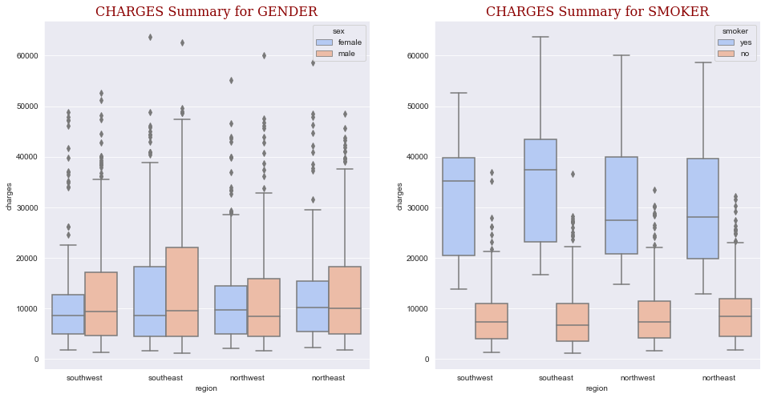

```python
fig=plt.figure(figsize=(16,8))

sns.set_style('darkgrid')
ax=fig.add_subplot(1,2,1)
sns.boxplot(y='charges',x='region',hue='sex', data=insur,palette='coolwarm')
ax.set_title('CHARGES Summary for GENDER', fontdict=font)

sns.set_style('darkgrid')
ax=fig.add_subplot(1,2,2)
sns.boxplot(y='charges',x='region',hue='smoker', data=insur,palette='coolwarm')
ax.set_title('CHARGES Summary for SMOKER', fontdict=font)
```

**From the above two graphs it can be interpreted that:-**

1. Charges for smokers are high.
2. Charges for males are high.

EDA - Pair plot that includes all the columns of the data frame

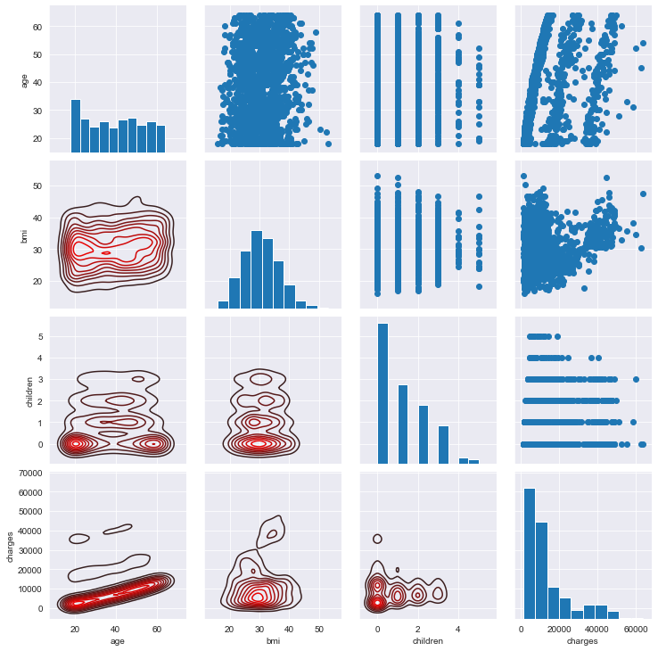

```python
sns.set_style('darkgrid')
g = sns.PairGrid(insur)
g.map_diag(plt.hist)
g.map_upper(plt.scatter)
g.map_lower(sns.kdeplot,color='r',shade=False)
```

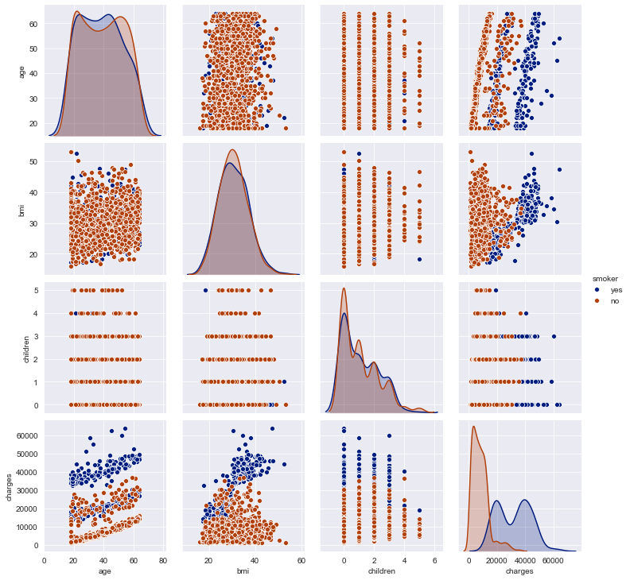

```python
sns.set_style('darkgrid')
sns.pairplot(insur,hue='smoker',palette='dark')
```

Removing Outliers - Not given in the project

```python
insur.head(3)
```

|  | age | sex | bmi | children | smoker | region | charges |
| --- | --- | --- | --- | --- | --- | --- | --- |
| 0 | 19 | female | 27.90 | 0 | yes | southwest | 16884.9240 |
| 1 | 18 | male | 33.77 | 1 | no | southeast | 1725.5523 |
| 2 | 28 | male | 33.00 | 3 | no | southeast | 4449.4620 |

```python
insur.shape
```

```
(1338, 7)
```

```python
num_train = insur.select_dtypes(include=["number"])
cat_train = insur.select_dtypes(exclude=["number"])
num_train
```

|  | age | bmi | children | charges |
| --- | --- | --- | --- | --- |
| 0 | 19 | 27.900 | 0 | 16884.92400 |
| 1 | 18 | 33.770 | 1 | 1725.55230 |
| 2 | 28 | 33.000 | 3 | 4449.46200 |
| 3 | 33 | 22.705 | 0 | 21984.47061 |
| 4 | 32 | 28.880 | 0 | 3866.85520 |
| ... | ... | ... | ... | ... |
| 1333 | 50 | 30.970 | 3 | 10600.54830 |
| 1334 | 18 | 31.920 | 0 | 2205.98080 |
| 1335 | 18 | 36.850 | 0 | 1629.83350 |
| 1336 | 21 | 25.800 | 0 | 2007.94500 |
| 1337 | 61 | 29.070 | 0 | 29141.36030 |

1338 rows × 4 columns

```python
from scipy import stats
import numpy as np
z=np.abs(stats.zscore(num_train))
print(z)
```

```
[[1.43876426 0.45332    0.90861367 0.2985838 ]
 [1.50996545 0.5096211  0.07876719 0.95368917]
 [0.79795355 0.38330685 1.58092576 0.72867467]
 ...
 [1.50996545 1.0148781  0.90861367 0.96159623]
 [1.29636188 0.79781341 0.90861367 0.93036151]
 [1.55168573 0.26138796 0.90861367 1.31105347]]
```

```python
threshold = 3
np.where(z > threshold)
```

```
(array([  32,   34,   71,  116,  166,  413,  425,  438,  543,  568,  577,
         640,  819,  847,  877,  932,  937,  969,  984, 1047, 1085, 1116,
        1130, 1146, 1230, 1245, 1272, 1300, 1317], dtype=int64),
 array([2, 3, 2, 1, 2, 2, 2, 2, 3, 2, 3, 2, 3, 1, 2, 2, 2, 2, 2, 1, 2, 2,
        2, 3, 3, 2, 2, 3, 1], dtype=int64))
```

```python
idx = np.all(stats.zscore(num_train) < 3, axis=1)
```

```python
train_cleaned = pd.concat([num_train.loc[idx], cat_train.loc[idx]], axis=1)
```

```python
df=train_cleaned
df
```

|  | age | bmi | children | charges | sex | smoker | region |
| --- | --- | --- | --- | --- | --- | --- | --- |
| 0 | 19 | 27.900 | 0 | 16884.92400 | female | yes | southwest |
| 1 | 18 | 33.770 | 1 | 1725.55230 | male | no | southeast |
| 2 | 28 | 33.000 | 3 | 4449.46200 | male | no | southeast |
| 3 | 33 | 22.705 | 0 | 21984.47061 | male | no | northwest |
| 4 | 32 | 28.880 | 0 | 3866.85520 | male | no | northwest |
| ... | ... | ... | ... | ... | ... | ... | ... |
| 1333 | 50 | 30.970 | 3 | 10600.54830 | male | no | northwest |
| 1334 | 18 | 31.920 | 0 | 2205.98080 | female | no | northeast |
| 1335 | 18 | 36.850 | 0 | 1629.83350 | female | no | southeast |
| 1336 | 21 | 25.800 | 0 | 2007.94500 | female | no | southwest |
| 1337 | 61 | 29.070 | 0 | 29141.36030 | female | yes | northwest |

1309 rows × 7 columns

Do charges of people who smoke differ significantly from the people who don't?

- **This is a two-tailed test.**
- **This is a test of comparison of means.**

**Ho = The means of CHARGES of SMOKERS and NON SMOKERS are equal.**

**Ha = The means of CHARGES of smokers and NON SMOKERS are significantly different.**

**Here, the sample is greater than 30, so we will use Z-test.**

**Here, we has assume the level of significance as 5%(alpha=5%)**

## Z-Statistics :-

```python
from scipy.stats import ttest_1samp, ttest_ind, mannwhitneyu, levene, shapiro
from statsmodels.stats.power import ttest_power
from statsmodels.stats.weightstats import ztest
```

```python
smoker = insur[insur['smoker']=='yes']['charges']
non_smoker = insur[insur['smoker']=='no']['charges']
```

```python
t_statistic, p_value = ztest(smoker, non_smoker)
print(t_statistic, p_value)
print ("two-sample t-test p-value=", p_value)
```

```
46.664921172723716 0.0
two-sample t-test p-value= 0.0
```

```python
if p_value < 0.05:
    print(f'With a p-value of {round(p_value,4)} the difference is significant. aka |We reject the null|')
else:
    print(f'With a p-value of {round(p_value,4)} the difference is not significant. aka |We fail to reject the null|')
```

```
With a p-value of 0.0 the difference is significant. aka |We reject the null|
```

**RESULT: With a p-value of 0.0 the difference is significant. aka |We reject the null|**

Investigating with different Statistics

## T-Statistics :-

```python
t_statistic, p_value = ttest_ind(smoker, non_smoker)
print(t_statistic, p_value)
print ("two-sample t-test p-value=", p_value)
```

```
46.664921172723716 8.271435842177219e-283
two-sample t-test p-value= 8.271435842177219e-283
```

```python
if p_value < 0.05:
    print(f'With a p-value of {round(p_value,4)} the difference is significant. aka |We reject the null|')
else:
    print(f'With a p-value of {round(p_value,4)} the difference is not significant. aka |We fail to reject the null|')
```

```
With a p-value of 0.0 the difference is significant. aka |We reject the null|
```

**With T-Statistics also, we get the same result as Z-Statistics**

Does bmi of males differ significantly from that of females

- **This is a two-tailed test.**
- **This is a test of comparison of means.**

**Ho = The means of BMI of MALES and FEMALES are equal.**

**Ha = The means of BMI of MALES and FEMALES are significantly different.**

**Here, the sample is greater than 30, so we will use Z-test.**

**Here, we has assume the level of significance as 5%(alpha=5%)**

## Z-Statistics :-

```python
males=insur[insur['sex']=='male']['bmi']
females=insur[insur['sex']=='female']['bmi']
```

```python
t_statistic, p_value = ztest(males, females)
print(t_statistic, p_value)
print ("two-sample t-test p-value=", p_value)
```

```
1.6967526357522242 0.08974343679943912
two-sample t-test p-value= 0.08974343679943912
```

```python
if p_value < 0.05:
    print(f'With a p-value of {round(p_value,4)} the difference is significant. aka |We reject the null|')
else:
    print(f'With a p-value of {round(p_value,4)} the difference is not significant. aka |We fail to reject the null|')
```

```
With a p-value of 0.0897 the difference is not significant. aka |We fail to reject the null|
```

**RESULT: With a p-value of 0.09 the difference is not significant. aka |We fail to reject the null|**

Investigating with different Statistics

## T-Statistics :-

```python
t_statistic, p_value = ttest_ind(males, females)
print(t_statistic, p_value)
print ("two-sample t-test p-value=", p_value)
```

```
1.696752635752224 0.08997637178984932
two-sample t-test p-value= 0.08997637178984932
```

```python
if p_value < 0.05:
    print(f'With a p-value of {round(p_value,4)} the difference is significant. aka |We reject the null|')
else:
    print(f'With a p-value of {round(p_value,4)} the difference is not significant. aka |We fail to reject the null|')
```

```
With a p-value of 0.09 the difference is not significant. aka |We fail to reject the null|
```

**With T-Statistics also, we get the same result as Z-Statistics**

Is the proportion of smokers significantly different in different genders

- **This is a two-tailed test.**
- **This is a test of proportions.**

**Ho = The proportion, of MALES and FEMALES, for smoking is equal.**

**Ha = The proportion, of MALES and FEMALES, for smoking is different.**

**Here, the sample is greater than 30, so we will use Z-test.**

**Here, we has assume the level of significance as 5%(alpha=5%)**

```python
f_smokers=insur[insur['sex']=='female']['smoker'].value_counts()
f_smokers=f_smokers['yes']

m_smokers=insur[insur['sex']=='male']['smoker'].value_counts()
m_smokers=m_smokers['yes']

print(f"The number of Female smokers:{f_smokers} \nThe number of Male smokers  :{m_smokers}")
```

```
The number of Female smokers:115
The number of Male smokers  :159
```

```python
females=(insur['sex']=='female').value_counts()
females=females[1]
females

males=(insur['sex']=='male').value_counts()
males=males[1]
males


print(f"The number of Females :{females} \nThe number of Males  :{males}")
```

```
The number of Females :662
The number of Males  :676
```

```python
P_F_smokers = (f_smokers/females).round(4)
P_M_smokers = (m_smokers/males).round(4)

print(f"The proportion of female smokers:{P_F_smokers*100}%\nThe proportion of male smokers  :{P_M_smokers*100}%")
```

```
The proportion of female smokers:17.37%
The proportion of male smokers  :23.52%
```

```python
from statsmodels.stats.proportion import proportions_ztest

stat, pval = proportions_ztest([f_smokers, m_smokers] , [females, males])

if pval < 0.05:
    print(f'With a p-value of {round(pval,4)} the difference is significant. aka |We reject the null|')
else:
    print(f'With a p-value of {round(pval,4)} the difference is not significant. aka |We fail to reject the null|')
```

```
With a p-value of 0.0053 the difference is significant. aka |We reject the null|
```

**RESULT: With a p-value of 0.0053 the difference is significant. aka |We reject the null|**

Is the distribution of bmi across women with no children, one child and two children, the same

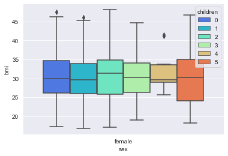

```python
df1=insur[insur['sex']=='female']
df1
sns.boxplot(x="sex", y="bmi", hue='children',data=df1,palette='rainbow')
```

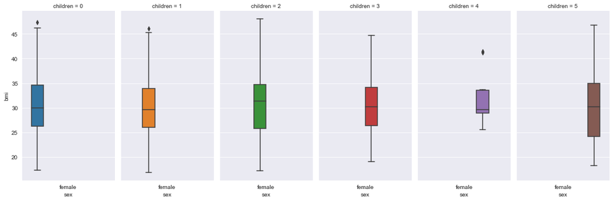

```python
g= sns.catplot(x="sex", y="bmi",
                hue="children",col='children',
                data=df1, kind="box",
                height=5, aspect=0.5);
```

From the above graphs for the BMI distribution of FEMALES for Children = 0,1 & 2 the observations are as follows:-